# Data analysis document: Pragmatic communicators can overcome asymmetry by exploiting ambiguity

Mark Blokpoel, Mark Dingemanse, George Kachergis, Sara Bögels, Ivan Toni, Iris van Rooij and the CABB team

# Introduction

# Packages and settings

Run the following code to install and load the required libraries.

```r
is_installed <- function(mypkg) is.element(mypkg, installed.packages()[,1])

load_or_install<-function(package_names)
{
  for(package_name in package_names)
  {
    if(!is_installed(package_name))
    {
      install.packages(package_name,repos="http://lib.stat.cmu.edu/R/CRAN")
    }
    library(package_name,character.only=TRUE,quietly=TRUE,verbose=FALSE)
  }
}

suppressWarnings(load_or_install(c("tidyverse",
                  "Hmisc",
                  "reshape2",
                  "extrafont",
                  "plyr",
                  "scales",
                  "RColorBrewer",
                  "grid",
                  "gtable",
                  "plotly",
                  "utils",
                  "data.table",
                  "ggnewscale",
                  "Rmisc")))

loadfonts(quiet = TRUE)

# these are some ggplot settings we use later
tre.12 <- element_text(size = 10, family = "LM Roman 10")
tre.14 <- element_text(size = 12, family = "LM Roman 10")
tre.16 <- element_text(size = 14, family = "LM Roman 10", hjust = 0.5)

ggplot_theme <- theme(panel.background = element_blank(), axis.line = element_line(colour = "black"),
                      panel.grid.major = element_line(colour = "grey"), panel.grid.minor = element_line(colour = "grey"),
                      axis.text = tre.14, axis.title = tre.16, legend.text = tre.12, legend.title = tre.14,
                      plot.title = tre.16)
```

# Main simulation: Pragmatic communicators can overcome asymmetry

Here we run analyses and generate the graphs reported for the main simulation. We define functions that are used to perform the same analysis for the Supporting Information.

## Loading data and pre-processing

We load the data in `.csv` format, remove incomplete cases, round down ambiguity values and remove instances where ambiguity for either agent is 0. Set the variable `dataFolder` to point towards the location where the collection of data files is stored. The script loads all `.csv`-files from that folder. Set the variable `tag` to a string that will be added to all output files. Default location to save PDF files is in `dataFolder`, you can set `writePDF` to `FALSE` to disable PDF output.

```r
# location of the data
dataFolder = "/Users/Mark/Google Drive/Big Question 3/Development/Data/30-8/uniform2000"
# location and tags for output files
outputFolder = dataFolder
tag = "uniform2000_30-8_"
writePDF = TRUE
supportingInfo = TRUE
writeSupportingPDF = TRUE

initializeOutput <- function(folder, tag) {
  # initialize output
  outputFolder = paste0(folder, "/figs/")
  dir.create(file.path(outputFolder), showWarnings = FALSE)
  return(paste0(outputFolder, tag))
}

loadAndPreprocessData <- function(folder) {
  # load the files
  csvFiles = list.files(path=folder, pattern="*.csv")
  data <- do.call("rbind", lapply(csvFiles, function(fn)
    data.frame(Filename=fn, read.csv(paste0(dataFolder, "/" ,fn))
    )))
  # remove header data
  data <- data[, !(names(data) %in% c("Filename"))]
  # round down ambiguity values
  data$agent1AmbiguityMean = floor(data$agent1AmbiguityMean)
  data$agent2AmbiguityMean = floor(data$agent2AmbiguityMean)
  # remove incomplete cases and cases where ambiguity < 1
  return(data[complete.cases(data) & data$agent1AmbiguityMean>0 & data$agent2AmbiguityMean>0, ])
}

outputPrefix <- initializeOutput(outputFolder, tag)
DFsim <- loadAndPreprocessData(dataFolder)
```

This next chunk filters out parts of the parameter space with fewer than $n=15$ samples. With so few samples, we do not get accurate means for these parts of the space. If this filters out too many parts you may need to run the simulation experiment with higher `sample-size`. (For this parameter see simulation software settings in the `application.conf` file.)

```r
filterData <- function(df) {
  DFsimFilter <- ddply(df,
                       c("agent1AmbiguityMean", "agent2AmbiguityMean", "asymmetry"),
                       summarise,
                       N = length(pairId))
  DFsimFilter <- DFsimFilter[DFsimFilter$N >= 15,]
  DFsimFilter <- merge(df, DFsimFilter, all = FALSE)
  return(DFsimFilter)
}

DFsim <- filterData(DFsim) # Comment out this line to include outliers.
```

Table 1 below displays 10 random rows from the preprocessed raw data. The columns are:

| column label | description | main paper reference |
| --- | --- | --- |
| `agent1AmbiguityMean` | lexicon ambiguity agent 1 | $$\mathrm{Mean}(\alpha_1)$$ |
| `agent2AmbiguityMean` | lexicon ambiguity agent 2 | $$\mathrm{Mean}(\alpha_2)$$ |
| `agent1AmbiguityVar` | variance in lexicon ambiguity agent 1 | $$\mathrm{Var}(\alpha_1)$$ |
| `agent2AmbiguityVar` | variance in lexicon ambiguity agent 2 | $$\mathrm{Var}(\alpha_2)$$ |
| `asymmetry` | asymmetry between agents | $$\gamma$$ |
| `agent1Order` | pragmatic order agent 1 | $$n$$ |
| `agent2Order` | pragmatic order agent 1 | $$n$$ |
| `averageSuccess` | communicative success for this pair over 35 trials | *mean success* is mean `averageSuccess` |
| `pairId` | pair identifier generated by simulation | n/a |
| `changeMethod` | method used to generate pair of agents | n/a |
| `changeRate` | parameter used in agent generation | n/a |
| `averageEntropyAsSpeaker` | average entropy of posterior distribution of speakers | n/a |
| `averageEntropyAsListener` | average entropy of posterior distribution of listeners | n/a |
| `N` | number of pairs of agents in same condition as this pair | n/a |

*Table 1: Random samples from preprocessed summarized data.*

|  | agent1AmbiguityMean | agent2AmbiguityMean | asymmetry | pairId | agent1Order | agent2Order | agent1AmbiguityVar | agent2AmbiguityVar | changeMethod | changeRate | averageSuccess | averageEntropyAsSpeaker | averageEntropyAsListener | N |
| --- | --- | --- | --- | --- | --- | --- | --- | --- | --- | --- | --- | --- | --- | --- |
| 3630559 | 7 | 7 | 0.1666667 | 1517219 | 1 | 1 | 0 | 0 | swap | 0.9 | 0.00000000 | 4.703982 | 2.803506 | 4398 |
| 3583824 | 7 | 7 | 0.0750000 | 5923168 | 1 | 1 | 0 | 0 | swap | 0.3 | 0.14285714 | 4.716079 | 2.805189 | 3732 |
| 1417811 | 3 | 7 | 0.5000000 | 5221090 | 1 | 1 | 0 | 0 | addition | 1.0 | 0.02857143 | 4.066179 | 2.186376 | 11907 |
| 4138413 | 8 | 8 | 0.0000000 | 4749377 | 2 | 2 | 0 | 0 | subtraction | 0.7 | 0.02857143 | 4.906891 | 3.000000 | 412629 |
| 2456544 | 5 | 7 | 0.3666667 | 1296354 | 0 | 0 | 0 | 0 | random | 0.8 | 0.05714286 | 4.445076 | 2.571576 | 513 |
| 3456238 | 7 | 7 | 0.0000000 | 1704099 | 0 | 0 | 0 | 0 | addition | 1.0 | 0.08571429 | 4.694267 | 2.807355 | 299751 |
| 200294 | 1 | 1 | 0.0500000 | 4105104 | 1 | 1 | 0 | 0 | swap | 0.3 | 0.88571429 | 1.814805 | 0.000000 | 3657 |
| 616736 | 2 | 2 | 0.0000000 | 1629551 | 2 | 2 | 0 | 0 | subtraction | 1.0 | 0.94285714 | 2.652904 | 0.881646 | 192054 |
| 1044259 | 3 | 3 | 0.0000000 | 1062399 | 0 | 0 | 0 | 0 | subtraction | 0.6 | 0.22857143 | 3.487549 | 1.584963 | 192318 |
| 2632737 | 6 | 5 | 0.4166667 | 834767 | 1 | 1 | 0 | 0 | random | 0.5 | 0.25714286 | 4.320112 | 2.444146 | 1587 |

### Compute statistics

Many scripts below require summary statistics of the data. We compute these statistics for each condition, `agent1AmbiguityMean` $\times$ `agent2AmbiguityMean` $\times$ `asymmetry` $\times$ `agent1order`. Note that both agents in this simulation always have the same order of pragmatic inference (`agent1order` $=$ `agent2order`).

```r
computeSummaryStatistics <- function(df) {
  suppressWarnings(summary <- ddply(df,
                 c("agent1AmbiguityMean", "agent2AmbiguityMean", "asymmetry", "agent1Order"),
                 summarise,
                 N    = length(averageSuccess),
                 mean = mean(averageSuccess),
                 sd   = sd(averageSuccess),
                 se   = sd / sqrt(N),
                 lower_ci = mean - qt(1-(0.05/2), N-1) * se,
                 upper_ci = mean + qt(1-(0.05/2), N-1) * se
  ))
  return(summary)
}

DFstats <- computeSummaryStatistics(DFsim)
```

*Table: Random samples from summary statistics.*

|  | agent1AmbiguityMean | agent2AmbiguityMean | asymmetry | agent1Order | N | mean | sd | se | lower_ci | upper_ci |
| --- | --- | --- | --- | --- | --- | --- | --- | --- | --- | --- |
| 3423 | 7 | 5 | 0.38333333 | 2 | 473 | 0.12823920 | 0.06218919 | 0.002859462 | 0.12262035 | 0.1338581 |
| 2808 | 6 | 2 | 0.70833333 | 2 | 6 | 0.08571429 | 0.09731078 | 0.039726959 | -0.01640711 | 0.1878357 |
| 36 | 1 | 1 | 0.09166667 | 2 | 1071 | 0.63460051 | 0.09312966 | 0.002845727 | 0.62901667 | 0.6401843 |
| 2719 | 6 | 1 | 0.68333333 | 0 | 948 | 0.12706450 | 0.05552362 | 0.001803323 | 0.12352552 | 0.1306035 |
| 1395 | 3 | 6 | 0.54166667 | 2 | 508 | 0.13442070 | 0.07866892 | 0.003490369 | 0.12756333 | 0.1412781 |
| 3391 | 7 | 4 | 0.55000000 | 0 | 83 | 0.12461274 | 0.05365270 | 0.005889149 | 0.11289734 | 0.1363281 |
| 3325 | 7 | 3 | 0.60833333 | 0 | 648 | 0.12570547 | 0.05563794 | 0.002185665 | 0.12141361 | 0.1299973 |
| 661 | 2 | 4 | 0.42500000 | 0 | 33 | 0.15497835 | 0.05298744 | 0.009223929 | 0.13618983 | 0.1737669 |
| 3364 | 7 | 4 | 0.47500000 | 0 | 443 | 0.12518542 | 0.05659936 | 0.002689117 | 0.11990038 | 0.1304705 |
| 1666 | 4 | 3 | 0.50000000 | 0 | 545 | 0.12644823 | 0.05539935 | 0.002373048 | 0.12178677 | 0.1311097 |

## Analyses

### Analysis 1: Theoretical and simulation population distribution

First, we compute the theoretical relationship between the ambiguity of two lexicons $\alpha_1$ and $\alpha_2$ and their asymmetry $\gamma$.

$$\begin{align}
\gamma_{\min}&=&1-\frac{1}{|R|}(\min(\alpha_1,\alpha_2)+\min(|R|-\alpha_1,|R|-\alpha_2)\\
\gamma_{\max}&=&\frac{1}{|R|}(\min(\alpha_1, |R|-\alpha_2)+\min(|R|-\alpha_1,\alpha_2)\\
\gamma_{\mathrm{mean}}&=&\frac{\alpha_1+\alpha_2}{|R|}-\frac{2\alpha_1\alpha_2}{|R|^2}
\end{align}$$

```r
numberOfReferents = 8
a1s <- 1:numberOfReferents
a2s <- 1:numberOfReferents
DFminMax <- data.frame(matrix(ncol = 5, nrow = 0))
x <- c("ambiguity1", "ambiguity2", "mina", "meana", "maxa")
colnames(DFminMax) <- x

for(a1 in a1s) {
  for(a2 in a2s) {
    maxAsymmetry <- (min(a1,numberOfReferents-a2)+min(a2,numberOfReferents-a1))/numberOfReferents
    meanAsymmetry <- a1/numberOfReferents + a2/numberOfReferents - 2*a1*a2/(numberOfReferents*numberOfReferents)
    minAsymmetry <- 1-(min(a1,a2) + min(numberOfReferents-a1,numberOfReferents-a2))/numberOfReferents

    newRow <- data.frame(agent1AmbiguityMean=a1,agent2AmbiguityMean=a2,mina=minAsymmetry,meana=meanAsymmetry,maxa=maxAsymmetry)
    DFminMax <- rbind(DFminMax, newRow)
  }
}

plotTheoreticalDistribution <- function(legendPos = "none", nrCols = 3) {
  ggplot(DFminMax, aes(x = agent1AmbiguityMean, y = meana)) +
  ggplot_theme +
  theme(panel.grid.major = element_blank(),
        panel.grid.minor = element_blank(),
        legend.position = legendPos) +
  scale_y_continuous(bquote("asymmetry"~gamma), breaks = pretty_breaks(5)) +
  scale_x_continuous(bquote("ambiguity"~alpha[1]), breaks = pretty_breaks(8)) +
  scale_fill_manual("", values = c("theoretical distribution" = "#d95f02")) +
  geom_crossbar(aes(ymin = mina, ymax = maxa, fill = "theoretical distribution")) +
  facet_wrap(. ~ agent2AmbiguityMean, labeller = label_bquote(cols=.(agent2AmbiguityMean)/.(numberOfReferents)), ncol = nrCols)
}
```

*Figure 3: Theoretical population distribution.*

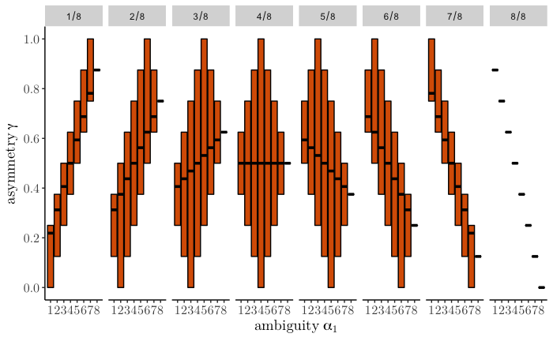

We can analyze how the samples generated in the simulation are distributed over this theoretically possible space. To do this, we summarize for each condition `agent1AmbiguityMean` $\times$ `agent2AmbiguityMean` $\times$ `asymmetry` the number of samples and transform them to $\log$-space for readibility.

```r
computeDistributionStatistics <- function(dfsim) {
  distributionStats <- ddply(dfsim[dfsim$agent1Order==0,],
                    c("agent1AmbiguityMean", "agent2AmbiguityMean", "asymmetry"),
                    summarise,
                    N = log(length(asymmetry)))
  distributionStats$N <- distributionStats$N / max(distributionStats$N)
  return(distributionStats)
}

plotMainSimulationDistribution <- function(distributionStats, theoreticalLims = FALSE, legendPos = "none") {
  GGdistribution <- ggplot(distributionStats) +
  ggplot_theme +
  theme(panel.grid.major = element_line(colour="gray"),
        panel.grid.minor = element_blank(),
        axis.ticks.y = element_blank(),
        axis.line.y = element_blank(),
        axis.text.y = element_blank(),
        legend.position = legendPos) +
  scale_y_continuous(bquote("asymmetry"~gamma), breaks = pretty_breaks(1)) +
  scale_x_continuous("", breaks = pretty_breaks(1)) +
  scale_fill_manual("", values = c("sample distribution" = "#1b9e77")) +
  scale_color_manual("", values = c("sample distribution" = "#1b9e77")) +
  scale_shape_manual("", values = c("theoretical minimum" = 91, "theoretical mean" = 5, "theoretical maximum" = 93)) +
  geom_rect(aes(xmin = 0, xmax = N, ymin = asymmetry, ymax = asymmetry, fill = "sample distribution", color = "sample distribution")) +
  facet_grid(agent2AmbiguityMean ~ agent1AmbiguityMean,
             labeller=label_bquote(rows=.(agent2AmbiguityMean)/.(8),
                                   cols=.(agent1AmbiguityMean)/.(8))) +
  coord_flip()


  if(theoreticalLims) {
    GGdistribution <- GGdistribution +
      geom_point(data = DFminMax, aes(x = 0.2, y = mina, shape = "theoretical minimum"), color = "#d95f02", size = 3.5) +
      geom_point(data = DFminMax, aes(x = 0.2, y = maxa, shape = "theoretical maximum"), color = "#d95f02", size = 3.5) +
      geom_point(data = DFminMax, aes(x = 0.2, y = meana, shape = "theoretical mean"), color = "#d95f02", size = 1.5)
  }
  return(GGdistribution)
}
```

*Figure S1: Simulation population distribution.*

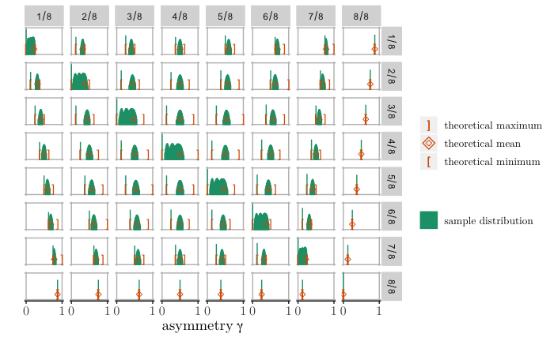

### Analysis 2: Main results

#### Preprocessing and analysis

We compute for each condition `agent1AmbiguityMean` $\times$ `agent2AmbiguityMean` how much more asymmetry 1<sup>st</sup> order agents can incurr, before their communicative success drops below that of the best 0 order agents. We filter zero order agents’ and first order agents’ data from the general dataframe `simDF`. For each of these two subsets we compute summary statistics, i.e., the mean successrates over pairs of agents in each condition. Here, the conditions are `agent1AmbiguityMean` $\times$ `agent2AmbiguityMean` $\times$ `asymmetry`.

```r
computeSummaryPerOrder <- function(dfsim, order) {
  dforder <- dfsim[dfsim$agent1Order==order,
                       c("pairId",
                         "agent1Order",
                         "agent2Order",
                         "agent1AmbiguityMean",
                         "agent2AmbiguityMean",
                         "asymmetry",
                         "averageSuccess")]

  dforderSummary <- ddply(dforder,
                              c("agent1AmbiguityMean",
                                "agent2AmbiguityMean",
                                "asymmetry"),
                              summarise,
                              meanSuccess = mean(averageSuccess))
  return(list(dforder = dforder, dforderSummary = dforderSummary))
}

result <- computeSummaryPerOrder(DFsim, 0)
DFdeltaOrder0 <- result$dforder
DFdeltaOrder0Summary <- result$dforderSummary
result <- computeSummaryPerOrder(DFsim, 1)
DFdeltaOrder1<- result$dforder
DFdeltaOrder1Summary <- result$dforderSummary
```

*Table: Random samples from zero-order summary statistics*

|  | agent1AmbiguityMean | agent2AmbiguityMean | asymmetry | meanSuccess |
| --- | --- | --- | --- | --- |
| 268 | 2 | 6 | 0.5666667 | 0.13351648 |
| 126 | 1 | 7 | 0.8250000 | 0.09495798 |
| 296 | 2 | 7 | 0.7083333 | 0.11824904 |
| 1014 | 6 | 6 | 0.1250000 | 0.15302386 |
| 944 | 6 | 3 | 0.5333333 | 0.12986395 |
| 80 | 1 | 4 | 0.5500000 | 0.07420635 |
| 214 | 2 | 3 | 0.4833333 | 0.09513344 |
| 568 | 4 | 3 | 0.6000000 | 0.07346939 |
| 987 | 6 | 5 | 0.3916667 | 0.13298701 |
| 127 | 1 | 7 | 0.8333333 | 0.11190476 |

*Table: Random samples from first-order summary statistics*

|  | agent1AmbiguityMean | agent2AmbiguityMean | asymmetry | meanSuccess |
| --- | --- | --- | --- | --- |
| 898 | 5 | 7 | 0.46666667 | 0.10612245 |
| 306 | 3 | 1 | 0.35000000 | 0.19579832 |
| 351 | 3 | 3 | 0.09166667 | 0.50262971 |
| 1008 | 6 | 6 | 0.07500000 | 0.25824974 |
| 1173 | 7 | 7 | 0.04166667 | 0.19798746 |
| 521 | 4 | 2 | 0.42500000 | 0.17000000 |
| 102 | 1 | 6 | 0.63333333 | 0.14285714 |
| 149 | 2 | 2 | 0.05833333 | 0.70085470 |
| 194 | 2 | 2 | 0.43333333 | 0.05274725 |
| 31 | 1 | 1 | 0.25000000 | 0.00000000 |

Next, we compute the minimum asymmetry in each `agent1AmbiguityMean` $\times$ `agent2AmbiguityMean` condition.

```r
computeMinimumAsymmetry <- function(dfOrderSummary) {
  deltaMinAsymmetry <- dfOrderSummary %>%
                       group_by(agent1AmbiguityMean, agent2AmbiguityMean) %>%
                       top_n(-1, asymmetry)
  deltaMinAsymmetry$meanSuccess <- NULL
  deltaMinAsymmetry$maxSuccess <- NULL
  colnames(deltaMinAsymmetry) <- c("agent1AmbiguityMean", "agent2AmbiguityMean", "minAsymmetry")
  return(deltaMinAsymmetry)
}

DFdeltaMinAsymmetry <- computeMinimumAsymmetry(DFdeltaOrder1Summary)
```

*Table: Random samples from minimum asymmetry*

[output not shown]

We then compute the maximum mean communicative success rate for 0 order agents in each `agent1AmbiguityMean` $\times$ `agent2AmbiguityMean` condition.

```r
computeMaxSuccess <- function(dfDeltaOrderSummary) {
  deltaMaxSuccessOrder <- tapply(dfDeltaOrderSummary$meanSuccess,
                                  list(dfDeltaOrderSummary$agent1AmbiguityMean, dfDeltaOrderSummary$agent2AmbiguityMean),
                                  max)
  dimnames(deltaMaxSuccessOrder) <- list(agent1AmbiguityMean=1:max(dfDeltaOrderSummary$agent1AmbiguityMean), agent2AmbiguityMean=1:max(dfDeltaOrderSummary$agent2AmbiguityMean))
  deltaMaxSuccessOrder <- as.data.frame(as.table(deltaMaxSuccessOrder))
  colnames(deltaMaxSuccessOrder) <- c("agent1AmbiguityMean", "agent2AmbiguityMean", "maxSuccess")
  return(deltaMaxSuccessOrder)
}

DFdeltaMaxSuccessOrder0 <- computeMaxSuccess(DFdeltaOrder0Summary)
```

|  | agent1AmbiguityMean | agent2AmbiguityMean | maxSuccess |
| --- | --- | --- | --- |
| 34 | 2 | 5 | 0.2011679 |
| 59 | 3 | 8 | 0.1225551 |
| 25 | 1 | 4 | 0.2457826 |
| 17 | 1 | 3 | 0.3354983 |
| 16 | 8 | 2 | 0.1247781 |

#### Communicative success

Having computed the mean communicative success rates for each condition, we merge these data frames, compute the intersection by finding the first data point on the above and below of the best 0 order agents’ success rate. If the intersection is not exactly on one of these points, we assume a linear relation between those two points and compute the intersection with that function.

```r
computeDeltaStatistics <- function(dfdeltaOrder1Summary, dfdeltaMaxSuccessOrder0) {
  dfdelta <- merge(x=dfdeltaOrder1Summary, y=dfdeltaMaxSuccessOrder0, by = c("agent1AmbiguityMean", "agent2AmbiguityMean"))

  DFdeltaUpperbounds <- dfdelta[dfdelta$meanSuccess>=dfdelta$maxSuccess,]
  DFdeltaUpperbounds <- DFdeltaUpperbounds %>% group_by(agent1AmbiguityMean, agent2AmbiguityMean) %>% top_n(1, asymmetry)
  DFdeltaLowerbounds <- dfdelta[dfdelta$meanSuccess<=dfdelta$maxSuccess,]
  DFdeltaLowerbounds <- DFdeltaLowerbounds %>% group_by(agent1AmbiguityMean, agent2AmbiguityMean) %>% top_n(-1, asymmetry)
  DFdeltaLowerbounds$maxSuccess <- NULL

  dfdelta <- merge(x=DFdeltaLowerbounds, y=DFdeltaUpperbounds, by = c("agent1AmbiguityMean", "agent2AmbiguityMean"))
  dfdelta <- merge(x=dfdelta, y=DFdeltaMinAsymmetry, by = c("agent1AmbiguityMean", "agent2AmbiguityMean"))

  dfdelta$a <- ifelse(dfdelta$asymmetry.x == dfdelta$asymmetry.y,
    dfdelta$asymmetry.x - dfdelta$minAsymmetry
  ,
    (dfdelta$asymmetry.y - dfdelta$asymmetry.x) /
    (dfdelta$meanSuccess.y - dfdelta$meanSuccess.x) *
    (dfdelta$maxSuccess - dfdelta$meanSuccess.y) +
    dfdelta$asymmetry.y - dfdelta$minAsymmetry
  )

  return(dfdelta)
}

plotCommSuccess = function(dfstats, dfdelta, a1, a2, legendPos = "none", axis = FALSE) {
  ggplot(dfstats[dfstats$agent1AmbiguityMean==a1 & dfstats$agent2AmbiguityMean==a2 & dfstats$agent1Order<2,]) +
  ggplot_theme +
  theme(panel.grid.major = element_blank(),
        panel.grid.minor = element_blank(),
        axis.text = element_text(size = 14),
        axis.title.x = if(axis) element_text(size = 24) else element_blank(),
        axis.title.y = if(axis) element_text(size = 24) else element_blank(),
        legend.position = legendPos) +
  scale_y_continuous("mean success rate", breaks=c(0,0.25,0.5,0.75,1.0), labels = c("0", rep("", 3), "1"), limits = c(0,1)) +
  scale_x_continuous(bquote("asymmetry"~gamma), breaks = c(0, 0.2, 0.4, 0.6), labels = c("0", "", "", ".6"), limits = c(0,0.6)) +
  geom_line(aes(x = asymmetry, y = mean, color = factor(agent1Order))) +
  geom_point(data = dfdelta[dfdelta$agent1AmbiguityMean==a1 & dfdelta$agent2AmbiguityMean==a2,],
             aes(shape = "intersection", x = a+minAsymmetry, y = maxSuccess), size = 5, show.legend = TRUE) +
  geom_point(data = dfdelta[dfdelta$agent1AmbiguityMean==a1 & dfdelta$agent2AmbiguityMean==a2,],
             aes(shape = "0 order max", x = minAsymmetry, y = maxSuccess), size = 5, show.legend = TRUE) +
  geom_segment(data = dfdelta[dfdelta$agent1AmbiguityMean==a1 & dfdelta$agent2AmbiguityMean==a2,],
               aes(linetype = "delta", x = minAsymmetry, y = maxSuccess, xend = a+minAsymmetry, yend = maxSuccess)) +
  scale_color_brewer("order of pragmatic inference", palette = "Dark2",
                     guide = guide_legend(override.aes = list(
                       linetype = c("solid", "solid"),
                       shape = c(NA, NA)))) +
  scale_shape_manual("intersection", values = c("0 order max" = 2, "intersection" = 6)) +
  scale_linetype_manual("delta", values = c("delta" = "dashed"), guide = guide_legend(override.aes = list(shape = c(NA))))
}

DFdelta <- computeDeltaStatistics(DFdeltaOrder1Summary, DFdeltaMaxSuccessOrder0)
```

*Figure 2, Panel A: Communicative success and delta asymmetry illustration.* We can inspect the example graph, but you can change the ambiguity values to inspect different parts of the parameter space.

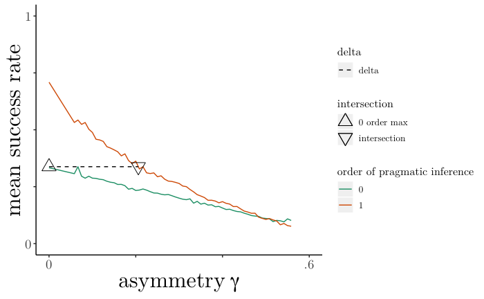

#### Delta asymmetry

This delta statistic is plotted in a heatmap below, for each `agent1AmbiguityMean` $\times$ `agent2AmbiguityMean` condition.

```r
plotDeltaAsymmetry = function(dfdelta, legendPos = "none") {
  ggplot(dfdelta, aes(x=factor(agent1AmbiguityMean), y=factor(agent2AmbiguityMean))) +
  ggplot_theme +
  theme(panel.grid.major = element_blank(),
        panel.grid.minor = element_blank(),
        axis.text = element_text(size = 14),
        axis.title.x = element_text(size = 24),
        axis.title.y = element_text(size = 24),
        plot.title = element_text(size = 24),
        legend.position = legendPos) +
  scale_y_discrete(bquote(ambiguity~alpha[2])) +
  scale_x_discrete(bquote(ambiguity~alpha[1])) +
  scale_fill_distiller("delta asymmetry", palette = "BuGn", direction = 1) +
  geom_tile(aes(fill=a))
}
```

*Figure 2, Panel B: Delta asymmetry heatmap.*

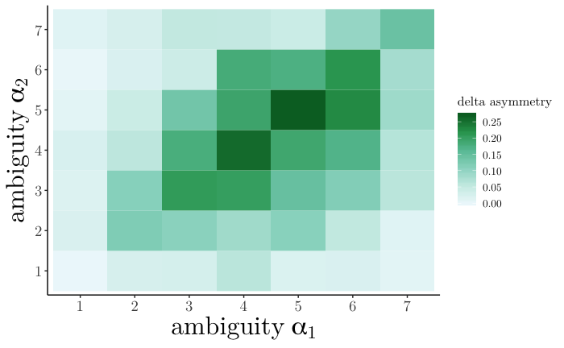

### Analysis 3: Replication and generalization

The following analysis shows a replication of the effect reported by Frank et al. (2017) that increasing orders of pragmatic inference has diminishing returns (in terms of communicative success). We compute summary statistics for second order agents, then subtract communicative success of first order agents from second order agents. As a control we also compute the difference in communicative success between first and zero order agents. To replicate the effect, the first analysis should yield values around 0, and the second analysis should yield values greater than 0.

```r
computeReplicationStatistics <- function(dfDeltaUpper, dfDeltaLower, upperOrder, lowerOrder) {
  replication <- within(merge(dfDeltaUpper,dfDeltaLower, by="pairId"), {
    diffSuccess <- averageSuccess.x - averageSuccess.y
    ambiguity1 <- agent1AmbiguityMean.x
    ambiguity2 <- agent2AmbiguityMean.x
    asymmetry <- asymmetry.x
  })[, c("pairId","ambiguity1","ambiguity2","asymmetry" ,"diffSuccess")]

  replicationSummary <- ddply(replication,
                              c("ambiguity1","ambiguity2","asymmetry"),
                              summarise,
                              meanDiffSuccess = mean(diffSuccess),
                              comp = paste0("order ", upperOrder, " - order ", lowerOrder)
                              )
}

replicationLabeller <- function(a1max, a2max) {
  repLabels <- vector(mode="character", length=64)
  for(a1 in 1:a1max) {
    for(a2 in 1:a2max) {
      repLabels[a1+((a2-1)*max(a1max,a2max))] <- paste0(a2,"/",max(a1max,a2max),":",a1,"/",max(a1max,a2max))
    }
  }
  repLabels
}

plotReplication = function(dfreplication21summary, dfreplication10summary, legendPos = "none") {
 ggplot(dfreplication21summary, aes(x = asymmetry, y = meanDiffSuccess, color = factor(ambiguity1):factor(ambiguity2), alpha = 0.5)) +
  ggplot_theme +
  theme(panel.grid.major = element_blank(),
      panel.grid.minor = element_blank(),
      axis.text = element_text(),
      axis.text.x = element_text(),
      axis.text.y = element_text(),
      legend.position = legendPos) +
  scale_y_continuous("mean difference success", breaks = pretty_breaks(5), limits = c(-0.07,0.5)) +
  scale_x_continuous(bquote(asymmetry~gamma), breaks = pretty_breaks(3)) +
  scale_color_discrete(bquote("ambiguity"~alpha[1]~":"~"ambiguity"~alpha[2]), labels = replicationLabeller(max(DFreplication21Summary$ambiguity1),max( DFreplication21Summary$ambiguity2))) +
  geom_point() +
  geom_point(data = dfreplication10summary) +
  facet_wrap( ~ comp)
}

DFdeltaOrder2 <- computeSummaryPerOrder(DFsim, 2)$dforder
DFreplication21Summary <- computeReplicationStatistics(DFdeltaOrder2, DFdeltaOrder1, 2, 1)
DFreplication10Summary <- computeReplicationStatistics(DFdeltaOrder1, DFdeltaOrder0, 1, 0)
```

*Figure 4: Replication and generalization of Frank et al. (2017).*

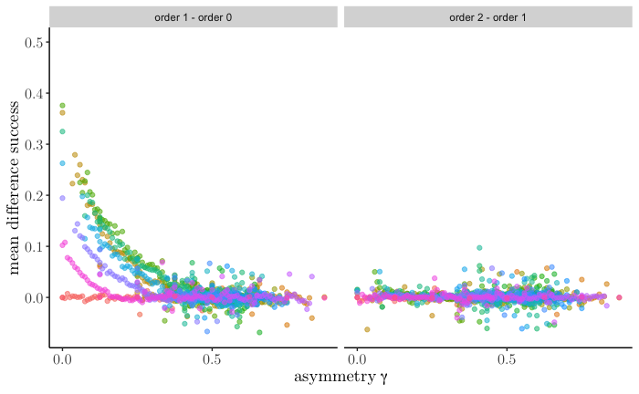

```r
plotReplication(DFreplication21Summary, DFreplication10Summary)
```

## Export figures to PDF

The following code chunk exports the figures to PDF. The figures in the main paper have been edited and combined using an external PDF editor, hence the ‘raw’ figures outputted here may differ slightly from the actual figures in the paper.

```r
if(writePDF) {
  pdf(file = paste0(outputPrefix, "fig3_theoretical_distribution.pdf"), height = 4, width = 8)
  print(plotTheoreticalDistribution(legend = "none", nrCols = 8))
  dev.off()

  MPlayout <- matrix(c(11,12,3, 4, 5,
                       1, 1, 2, 2, 6,
                       1, 1, 2, 2, 7,
                       13,14,8, 9,10),
                     nrow = 4, byrow = TRUE)

  pdf(file = paste0(outputPrefix, "fig2_overview.pdf"), width = 15, height = 12)
  print(multiplot(plotCommSuccess(DFstats, DFdelta, 3, 3, axis = TRUE),
            plotDeltaAsymmetry(DFdelta),
            plotCommSuccess(DFstats, DFdelta, 4, 4), #3
            plotCommSuccess(DFstats, DFdelta, 4, 5), #4
            plotCommSuccess(DFstats, DFdelta, 5, 5), #5
            plotCommSuccess(DFstats, DFdelta, 5, 4), #6
            plotCommSuccess(DFstats, DFdelta, 4, 3), #7
            plotCommSuccess(DFstats, DFdelta, 1, 1), #8
            plotCommSuccess(DFstats, DFdelta, 2, 2), #9
            plotCommSuccess(DFstats, DFdelta, 3, 2), #10
            NULL, NULL, NULL, NULL, #11, 12, 13, 14
            cols = 5, layout = MPlayout))
  dev.off()

  pdf(file = paste0(outputPrefix, "fig2_communicative_success_legend.pdf"))
  print(plotCommSuccess(DFstats, DFdelta, 3, 3, legendPos = "right"))
  dev.off()

  pdf(file = paste0(outputPrefix, "fig2_delta_asymmetry_legend.pdf"))
  print(plotDeltaAsymmetry(DFdelta, legendPos = "right"))
  dev.off()

  pdf(file = paste0(outputPrefix, "fig4_replication.pdf"), height = 4, width = 8)
  print(plotReplication(DFreplication21Summary, DFreplication10Summary, legendPos = "none"))
  dev.off()

  pdf(file = paste0(outputPrefix, "fig4_replication_legend.pdf"), height = 7, width = 8)
  print(plotReplication(DFreplication21Summary, DFreplication10Summary, legendPos = "bottom"))
  dev.off()

  pdf(file = paste0(outputPrefix, "figs1_distribution.pdf"), height = 5, width = 8)
  print(plotMainSimulationDistribution(computeDistributionStatistics(DFsim), theoreticalLims = TRUE, legendPos = "right"))
  dev.off()
}
```

# Supporting Information

This section contains the analyses and figures reported in the Supporting Information document. There is one additional analyses, relative to the main study, which plots the variance in the ambiguity.

## Supporting Simulation I: Random generation

```r
if(supportingInfo) {
  dataFolder = "/Users/Mark/Google Drive/Big Question 3/Development/Data/30-8/random2000"
  # location and tags for output files
  outputFolder = dataFolder
  tag = "random2000_"

  outputPrefix <- initializeOutput(outputFolder, tag)
  DFsim <- loadAndPreprocessData(dataFolder)
  DFsim <- filterData(DFsim) # Comment out this line to include outliers.
  DFstats <- computeSummaryStatistics(DFsim)

  result <- computeSummaryPerOrder(DFsim, 0)
  DFdeltaOrder0 <- result$dforder
  DFdeltaOrder0Summary <- result$dforderSummary
  result <- computeSummaryPerOrder(DFsim, 1)
  DFdeltaOrder1<- result$dforder
  DFdeltaOrder1Summary <- result$dforderSummary

  DFdeltaMinAsymmetry <- computeMinimumAsymmetry(DFdeltaOrder1Summary)
  DFdeltaMaxSuccessOrder0 <- computeMaxSuccess(DFdeltaOrder0Summary)
  DFdelta <- computeDeltaStatistics(DFdeltaOrder1Summary, DFdeltaMaxSuccessOrder0)
  DFdeltaOrder2 <- computeSummaryPerOrder(DFsim, 2)$dforder
  DFreplication21Summary <- computeReplicationStatistics(DFdeltaOrder2, DFdeltaOrder1, 2, 1)
  DFreplication10Summary <- computeReplicationStatistics(DFdeltaOrder1, DFdeltaOrder0, 1, 0)
}
```

*Figure S2, Panel A: Generation procedure I (randomized), Mean communicative success for $\alpha_1=3$ and $\alpha_2=3$.*

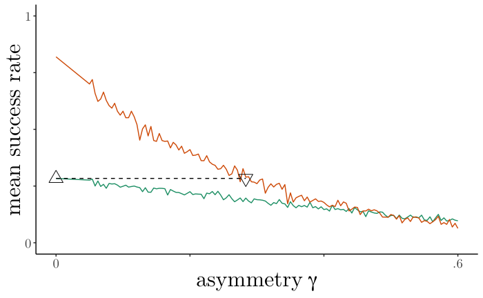

```r
if(supportingInfo) {
  plotCommSuccess(DFstats, DFdelta, 3, 3, axis = TRUE)
}
```

*Figure S2, Panel B: Generation procedure I (randomized), Increased asymmetry toleration.*

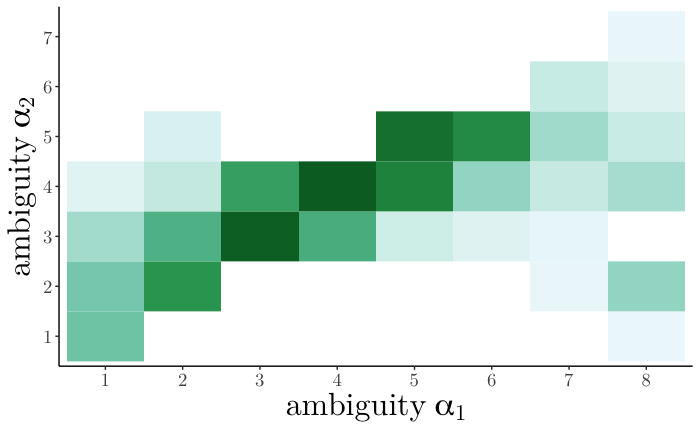

```r
if(supportingInfo) {
  plotDeltaAsymmetry(DFdelta)
}
```

*Figure S3, Panel B: Generation procedure I (randomized), Sample distribution.*

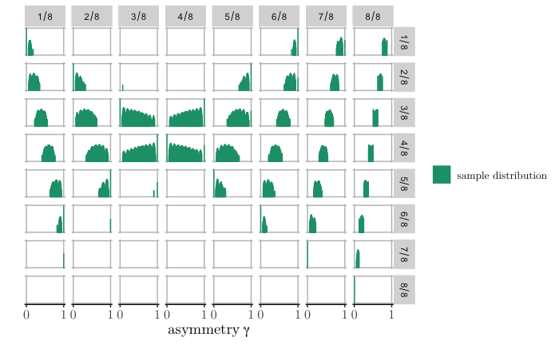

```r
if(supportingInfo) {
  plotMainSimulationDistribution(computeDistributionStatistics(DFsim), theoreticalLims = FALSE, legendPos = "right")
}
```

*Figure S4, Panel A: Generation procedure I (randomized), Replication and extension.*

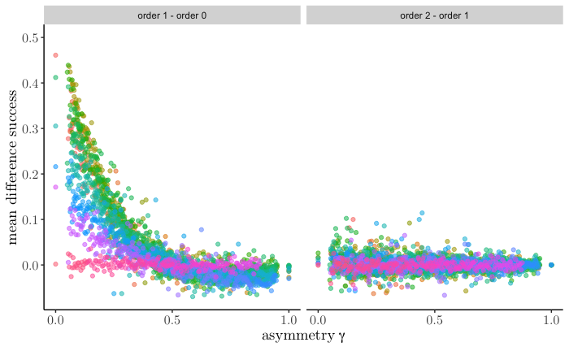

```r
if(supportingInfo) {
  plotReplication(DFreplication21Summary, DFreplication10Summary, legendPos = "none")
}
```

### Variance of ambiguity

Since the supporting simulations break the uniform ambiguity assumption, the variance of the lexicons generated here might be
$$>0$$
. We plot the distribution of variance of ambiguity below.

```r
plotVariance <- function(dfsim, legendPos = "none") {
  DFvariance <- rbind(data.frame(ag = 1, amb = dfsim$agent1AmbiguityMean, var = dfsim$agent1AmbiguityVar),
                    data.frame(ag = 2, amb = dfsim$agent2AmbiguityMean, var = dfsim$agent2AmbiguityVar))

  DFvariance$varBin <- as.numeric(paste(cut(DFvariance$var,
                           breaks=seq(min(DFvariance$var),max(DFvariance$var),0.125),
                           labels=seq(min(DFvariance$var),max(DFvariance$var)-0.125,0.125),
                           include.lowest = TRUE, right = TRUE)))

  DFvariance <- ddply(DFvariance,
                      c("ag", "amb", "varBin"),
                      summarise,
                      N = length(varBin))

  amax = max(DFvariance$amb)

  ggplot(DFvariance, aes(x = varBin, y = N, fill = factor(ag))) + ggplot_theme +
    theme(panel.grid.major = element_blank(),
      panel.grid.minor = element_blank(),
      axis.text = element_text(),
      axis.text.x = element_text(),
      axis.text.y = element_text(),
      legend.position = legendPos) +
    scale_y_log10("number of samples", labels = scales::comma) +
    scale_x_continuous("ambiguity variance", breaks = pretty_breaks(4)) +
    scale_fill_manual("agent", values = c("1" = "#7b3294", "2" = "#008837")) +
    geom_bar(position = "dodge", stat = "identity") +
    facet_wrap(amb ~ ., labeller = label_bquote(cols = alpha == ~ .(amb)/.(max(DFsim$agent1AmbiguityMean,DFsim$agent2AmbiguityMean))), ncol = 4)
}
```

*Figure S3, Panel A: Supporting simulation I variance of ambiguity.*

```
NAs introduced by coercion
```

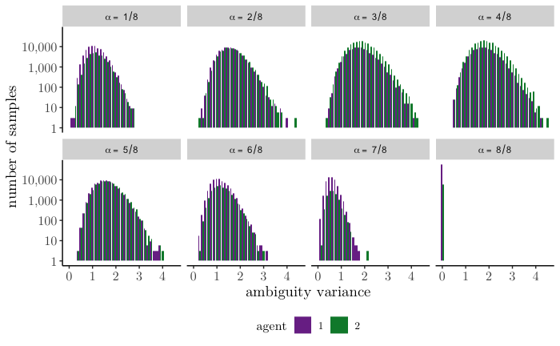

```r
if(supportingInfo) {
  plotVariance(DFsim, "bottom")
}
```

### Export figures to PDF

```r
# If the PDFs are not saved corretly, try running each PDF save manually.

if(writeSupportingPDF && supportingInfo) {
  pdf(file = paste0(outputPrefix, "figs2ab_random_overview.pdf"), width = 15, height = 12)
    MPlayout <- matrix(c(11,12,3, 4, 5,
                       1, 1, 2, 2, 6,
                       1, 1, 2, 2, 7,
                       13,14,8, 9,10),
                     nrow = 4, byrow = TRUE)
  print(multiplot(plotCommSuccess(DFstats, DFdelta, 3, 3, axis = TRUE),
            plotDeltaAsymmetry(DFdelta),
            plotCommSuccess(DFstats, DFdelta, 3, 4), #3
            plotCommSuccess(DFstats, DFdelta, 4, 4), #4
            plotCommSuccess(DFstats, DFdelta, 5, 5), #5
            plotCommSuccess(DFstats, DFdelta, 5, 4), #6
            plotCommSuccess(DFstats, DFdelta, 4, 3), #7
            plotCommSuccess(DFstats, DFdelta, 1, 1), #8
            plotCommSuccess(DFstats, DFdelta, 1, 2), #9
            plotCommSuccess(DFstats, DFdelta, 2, 2), #10
            NULL, NULL, NULL, NULL, #11, 12, 13, 14
            cols = 5, layout = MPlayout))
  dev.off()

  pdf(file = paste0(outputPrefix, "figs4a_random_replication.pdf"), height = 4, width = 8)
  print(plotReplication(DFreplication21Summary, DFreplication10Summary, legendPos = "none"))
  dev.off()

  pdf(file = paste0(outputPrefix, "figs3b_random_distribution.pdf"), height = 5, width = 8)
  print(plotMainSimulationDistribution(computeDistributionStatistics(DFsim), theoreticalLims = FALSE, legendPos = "right"))
  dev.off()

  pdf(file = paste0(outputPrefix, "figs3a_variance.pdf"), height = 3, width = 8)
  print(plotVariance(DFsim, "bottom"))
  dev.off()
}
```

## Supporting Simulation II: Structured generation

```r
if(supportingInfo) {
  dataFolder = "/Users/Mark/Google Drive/Big Question 3/Development/Data/30-8/structured2000"
  # location and tags for output files
  outputFolder = dataFolder
  tag = "structured2000_"

  outputPrefix <- initializeOutput(outputFolder, tag)
  DFsim <- loadAndPreprocessData(dataFolder)
  DFsim <- filterData(DFsim) # Comment out this line to include outliers.
  DFstats <- computeSummaryStatistics(DFsim)

  result <- computeSummaryPerOrder(DFsim, 0)
  DFdeltaOrder0 <- result$dforder
  DFdeltaOrder0Summary <- result$dforderSummary
  result <- computeSummaryPerOrder(DFsim, 1)
  DFdeltaOrder1<- result$dforder
  DFdeltaOrder1Summary <- result$dforderSummary

  DFdeltaMinAsymmetry <- computeMinimumAsymmetry(DFdeltaOrder1Summary)
  DFdeltaMaxSuccessOrder0 <- computeMaxSuccess(DFdeltaOrder0Summary)
  DFdelta <- computeDeltaStatistics(DFdeltaOrder1Summary, DFdeltaMaxSuccessOrder0)
  DFdeltaOrder2 <- computeSummaryPerOrder(DFsim, 2)$dforder
  DFreplication21Summary <- computeReplicationStatistics(DFdeltaOrder2, DFdeltaOrder1, 2, 1)
  DFreplication10Summary <- computeReplicationStatistics(DFdeltaOrder1, DFdeltaOrder0, 1, 0)
}
```

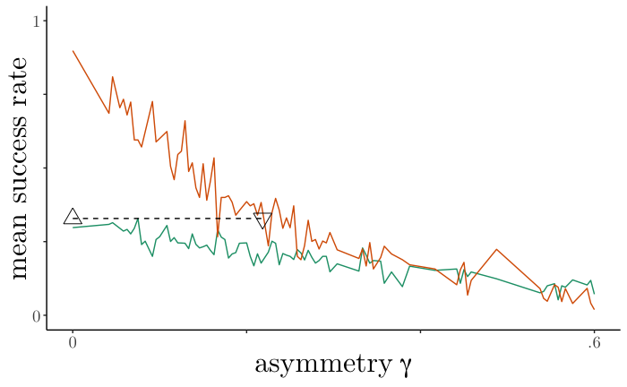

```r
if(supportingInfo) {
  plotCommSuccess(DFstats, DFdelta, 3, 3, axis = TRUE)
}
```

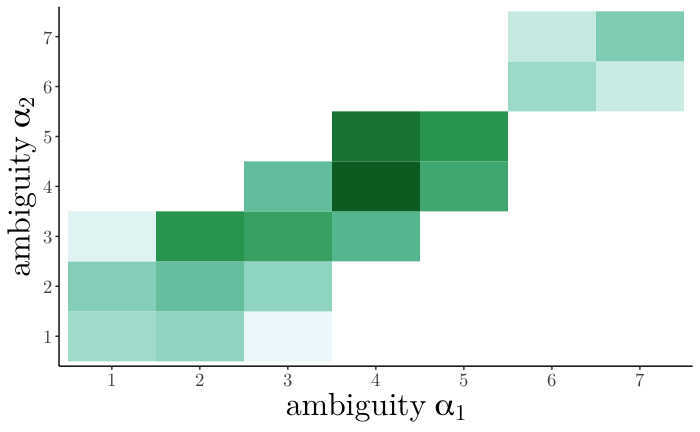

```r
if(supportingInfo) {
  plotDeltaAsymmetry(DFdelta)
}
```

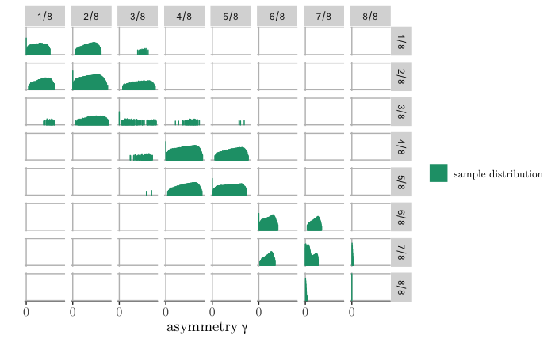

```r
if(supportingInfo) {
  plotMainSimulationDistribution(computeDistributionStatistics(DFsim), theoreticalLims = FALSE, legendPos = "right")
}
```

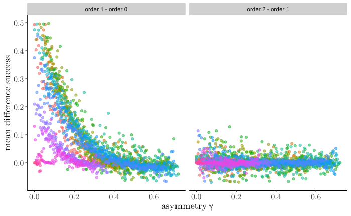

```r
if(supportingInfo) {
  plotReplication(DFreplication21Summary, DFreplication10Summary, legendPos = "none")
}
```

*Figure S3, Panel C: Supporting simulation II variance of ambiguity.*

```
NAs introduced by coercion
```

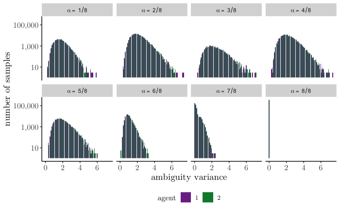

```r
if(supportingInfo) {
  plotVariance(DFsim, "bottom")
}
```

```r
# If the PDFs are not saved corretly, try running each PDF save manually.

if(writeSupportingPDF && supportingInfo) {
  pdf(file = paste0(outputPrefix, "figs2cd_structured_overview.pdf"), width = 15, height = 12)
    MPlayout <- matrix(c(11,12,3, 4, 5,
                       1, 1, 2, 2, 6,
                       1, 1, 2, 2, 7,
                       13,14,8, 9,10),
                     nrow = 4, byrow = TRUE)
  print(multiplot(plotCommSuccess(DFstats, DFdelta, 3, 3, axis = TRUE),
            plotDeltaAsymmetry(DFdelta),
            plotCommSuccess(DFstats, DFdelta, 4, 4), #3
            plotCommSuccess(DFstats, DFdelta, 4, 5), #4
            plotCommSuccess(DFstats, DFdelta, 5, 5), #5
            plotCommSuccess(DFstats, DFdelta, 5, 4), #6
            plotCommSuccess(DFstats, DFdelta, 4, 3), #7
            plotCommSuccess(DFstats, DFdelta, 1, 1), #8
            plotCommSuccess(DFstats, DFdelta, 2, 2), #9
            plotCommSuccess(DFstats, DFdelta, 3, 2), #10
            NULL, NULL, NULL, NULL, #11, 12, 13, 14
            cols = 5, layout = MPlayout))
  dev.off()

  pdf(file = paste0(outputPrefix, "figs4b_structured_replication.pdf"), height = 4, width = 8)
  print(plotReplication(DFreplication21Summary, DFreplication10Summary, legendPos = "none"))
  dev.off()

  pdf(file = paste0(outputPrefix, "figs3d_structured_distribution.pdf"), height = 5, width = 8)
  print(plotMainSimulationDistribution(computeDistributionStatistics(DFsim), theoreticalLims = FALSE, legendPos = "right"))
  dev.off()

  pdf(file = paste0(outputPrefix, "figs3c_variance.pdf"), height = 3, width = 8)
  print(plotVariance(DFsim, "bottom"))
  dev.off()
}
```